# Assignment 8: Phân vùng ảnh (Image Segmentation)

Tổng quan: Ở bài tập này chúng ta sẽ luyện tập thuật toán phân vùng ảnh sử dụng K-Means và Mean Shift. Các bài tập trong phần này yêu cầu bạn sử dụng các không gian đặc trưng khác nhau để biểu diễn các điểm ảnh, sau đó sử dụng K-Means và Mean Shift có sẵn trong thư viện sklearn để phân vùng ảnh

```python
import warnings
warnings.filterwarnings("ignore")

import matplotlib.pyplot as plt
import cv2
import numpy as np
from sklearn.cluster import KMeans
from sklearn.cluster import MeanShift
```

## Câu hỏi 1: Phân vùng ảnh xám

Ở phần này ta sẽ biểu diễn mỗi điểm ảnh bằng một vecto 1 chiều (không gian đặc trưng 1D): giá trị độ sáng tại điểm ảnh tương ứng

```
(183, 275, 3)
(183, 275)
```

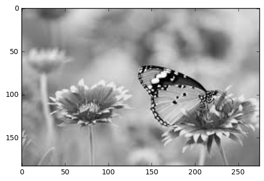

```python
img = cv2.imread('img1.jpg')
print(img.shape)
img = cv2.cvtColor(img, cv2.COLOR_BGR2GRAY)
print(img.shape)

plt.imshow(img, cmap='gray')
plt.show()
```

Xây dựng ma trận biểu diễn dữ liệu:

```python
X = img.reshape((-1, 1))
print(X.shape)
```

```
(50325, 1)
```

Lúc này mỗi hàng của ma trận X tương ứng với một vector biểu diễn một điểm ảnh trên ảnh ban đầu. Ta sẽ thử sử dụng thuật toán K-Means và MeanShift để phân vùng các điểm ảnh theo độ sáng của nó:

- KMeans

```
KMeans(algorithm='auto', copy_x=True, init='random', max_iter=300,
    n_clusters=10, n_init=10, n_jobs=1, precompute_distances='auto',
    random_state=None, tol=0.0001, verbose=0)
[[150.25382218]
 [163.31608157]
 [ 65.92907417]
 [ 96.85719598]
 [195.31505962]
 [ 14.63024142]
 [136.9866643 ]
 [121.40778608]
 [178.32350143]
 [216.42205323]]
(50325,)
```

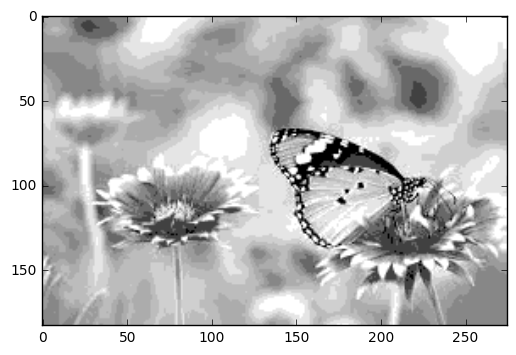

```python
kmeans = KMeans(n_clusters=10, init='random').fit(X)
print(kmeans)
center = kmeans.cluster_centers_
label = kmeans.labels_

print(center)
print(label.shape)

segmented_image = center[label]
segmented_image = np.reshape(segmented_image, img.shape)
plt.imshow(segmented_image, cmap='gray')
plt.show()
```

- MeanShift: Đối với MeanShift, ta cần một hàm để khởi tạo ngẫu nhiên các hạt seed:

```python
def init_seed(X, k):
    return X[np.random.choice(X.shape[0], k, replace=False)]
```

```
MeanShift(bandwidth=1, bin_seeding=False, cluster_all=True, min_bin_freq=1,
     n_jobs=1,
     seeds=array([[170],
       [193],
       [190],
       [140],
       [120],
       [156],
       [147],
       [116],
       [146],
       [210]], dtype=uint8))
[[156.51166966]
 [169.53853383]
 [147.47368421]
 [189.49013499]
 [140.46871686]
 [193.48593074]
 [120.48292683]
 [209.46885246]
 [116.54046243]]
(50325,)
```

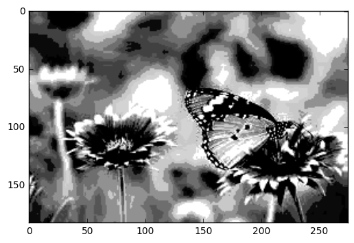

```python
random_seeds = init_seed(X, 10)

ms = MeanShift(bandwidth=1, seeds=random_seeds)
print(ms)
ms.fit(X)
center = ms.cluster_centers_
label = ms.labels_

print(center)
print(label.shape)

segmented_image = center[label]
segmented_image = np.reshape(segmented_image, img.shape)
plt.imshow(segmented_image/255.0, cmap='gray')
plt.show()
```